# Homework 10

Jhanani Ramkumar

2026-02-12

## Instructions

Answer the following questions and complete the exercises in RMarkdown. Please embed all of your code and push your final work to your repository. Your final lab report should be organized, clean, and run free from errors. Remember, you must remove the `#` for the included code chunks to run. Be sure to add your name to the author header above.

Make sure to use the formatting conventions of RMarkdown to make your report neat and clean!

## Background

In the `data` folder, you will find data about shark incidents in California between 1950-2022. The [data](https://catalog.data.gov/dataset/shark-incident-database-california-56167) are from: State of California- Shark Incident Database.

## Load the libraries

```r
library("tidyverse")
library("janitor")
```

## Load the data

Run the following code chunk to import the data. In this chunk, I am removing NA’s.

```r
sharks <-
  read_csv("data/SharkIncidents_1950_2022_220302.csv",
           na=c("NA", "N/A", "Unknown", "NOT COUNTED", "", " ")) %>%
  clean_names()
```

## Questions

1. Are there any “hotspots” for shark incidents in California? Show the top five counties with the most incidents.

```r
sharks %>%
  filter(!is.na(county)) %>%
  count(county, name = "total_incidents") %>%
  arrange(desc(total_incidents)) %>%
  slice_head(n=5)
```

```
## # A tibble: 5 × 2
##   county        total_incidents
##   <chr>                   <int>
## 1 San Diego                  25
## 2 Humboldt                   20
## 3 San Mateo                  19
## 4 Santa Barbara              19
## 5 Marin                      16
```

2. Make a plot that shows the total number of incidents per county.

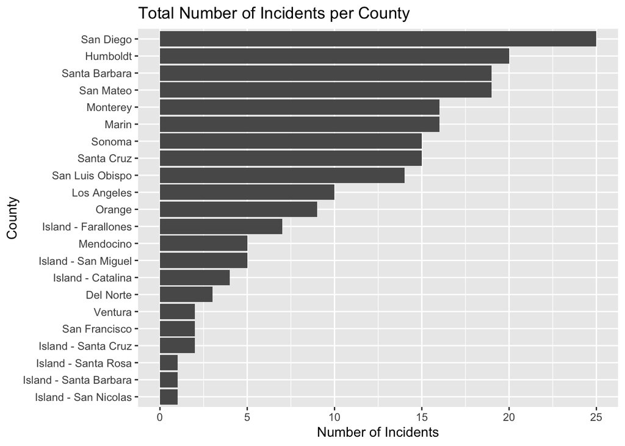

```r
sharks %>%
  filter(!is.na(county)) %>%
  count(county, name = "total_incidents") %>%
  ggplot(aes(x = reorder(county, total_incidents), y = total_incidents)) +
  geom_col()+
  coord_flip()+
  labs(title = "Total Number of Incidents per County", x="County", y="Number of Incidents")
```

3. Are there months of the year when incidents are more likely to occur? Make a plot that shows the total number of incidents by month. Which month has the highest number of incidents?

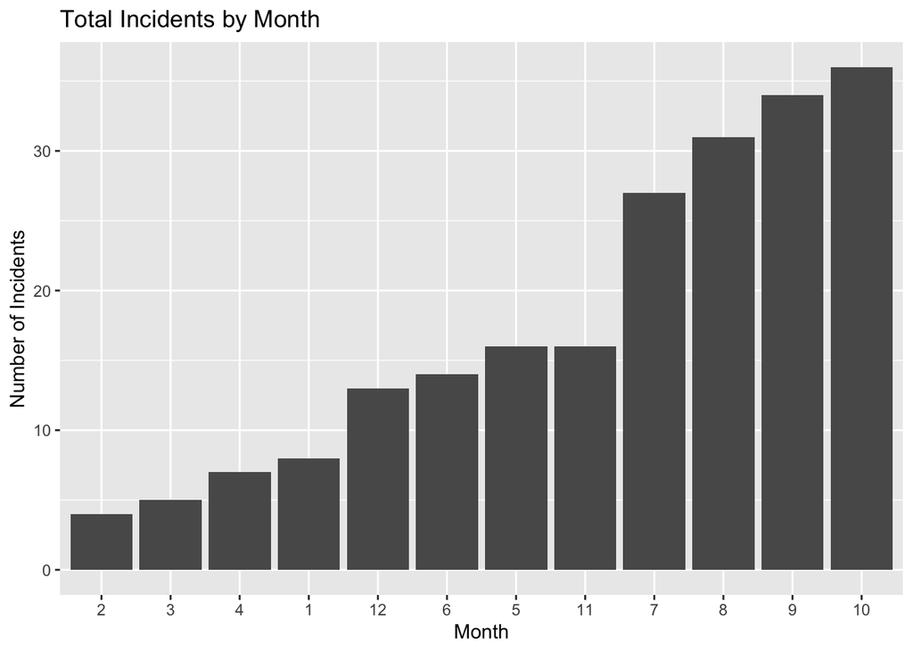

```r
sharks %>%
  filter(!is.na(month)) %>%
  count(month, name = "total_incidents") %>%
  ggplot(aes(x = reorder(month, total_incidents),
             y = total_incidents)) +
  geom_col()+
  labs(title = "Total Incidents by Month",
    x = "Month",
    y = "Number of Incidents")
```

October has the highest number of total incidents.

4. Is there a time of day when most attacks occur? Make a plot that shows the total number of incidents by time of day. Which time of day has the highest number of incidents?

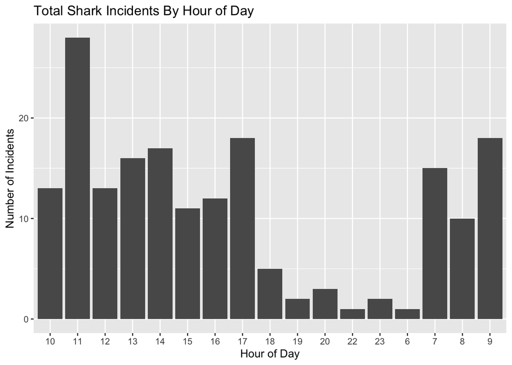

```r
sharks %>%
  filter(!is.na(time)) %>%
  filter(time != "early am",
         time != "afternoon") %>%
  separate(time, into = c("hour","minute"), sep = ":") %>%
  count(hour) %>%
  ggplot(aes(x = hour, y = n)) +
  geom_col() +
  labs(
    title = "Total Shark Incidents By Hour of Day",
    x = "Hour of Day",
    y = "Number of Incidents"
  )
```

Around 11am is when the number of incidents are the highest.

5. How do the number and types of injuries compare by county? Make a table that shows the number of injury types by county. Which county has the highest number incidents? (hint: your table should be in wide format)

```r
sharks_wide <- sharks %>%
  filter(!is.na(county)) %>%
  filter(!is.na(injury)) %>%
  filter(injury != "minor*",
         injury != "none*",
         injury != "major*",
         injury != "fatal*") %>%
  group_by(county, injury) %>%
  summarize(total = n()) %>%
  pivot_wider(names_from = injury,
              values_from = total)
sharks_wide
```

```
## # A tibble: 21 × 5
## # Groups:   county [21]
##    county               minor  none major fatal
##    <chr>                <int> <int> <int> <int>
##  1 Del Norte                2     1    NA    NA
##  2 Humboldt                 2     9     7    NA
##  3 Island - Catalina        1     3    NA    NA
##  4 Island - Farallones     NA    NA     7    NA
##  5 Island - San Miguel      2    NA     2     1
##  6 Island - San Nicolas     1    NA    NA    NA
##  7 Island - Santa Cruz      1     1    NA    NA
##  8 Island - Santa Rosa     NA    NA     1    NA
##  9 Los Angeles              6     2    NA     1
## 10 Marin                    4     3     9    NA
## # ℹ 11 more rows
```

```r
sharks_new_wide <- sharks_wide %>%
  mutate(
    total_incidents =
      ifelse(is.na(minor), 0, minor) +
      ifelse(is.na(none), 0, none) +
      ifelse(is.na(major), 0, major) +
      ifelse(is.na(fatal), 0, fatal)
  )
sharks_new_wide %>%
  arrange(desc(total_incidents))
```

```
## # A tibble: 21 × 6
## # Groups:   county [21]
##    county          minor  none major fatal total_incidents
##    <chr>           <int> <int> <int> <int>           <dbl>
##  1 San Diego           8     9     4     2              23
##  2 Santa Barbara       6     9     2     2              19
##  3 Humboldt            2     9     7    NA              18
##  4 San Mateo           4    12     1     1              18
##  5 Marin               4     3     9    NA              16
##  6 Monterey            2     3     8     2              15
##  7 Santa Cruz          3     8     3     1              15
##  8 Sonoma              1     6     8    NA              15
##  9 San Luis Obispo     1     7     3     3              14
## 10 Los Angeles         6     2    NA     1               9
## # ℹ 11 more rows
```

The county with the highest number of incidents is San Diego.

6. Use the table from #5 to make a plot that shows the total number of incidents by county.

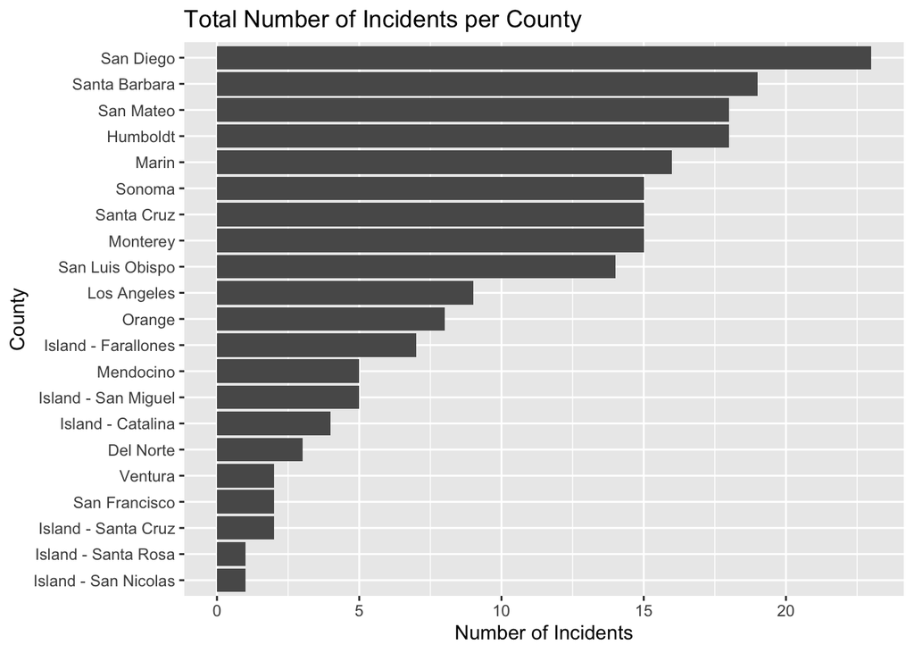

```r
sharks_new_wide %>%
  ggplot(aes(x = reorder(county, total_incidents), y = total_incidents)) +
  geom_col()+
  coord_flip()+
  labs(title = "Total Number of Incidents per County", x="County", y="Number of Incidents")
```

7. In the data, `mode` refers to a type of activity. Which activity is associated with the highest number of incidents?

```r
sharks %>%
  filter(!is.na(mode)) %>%
  count(mode, sort = TRUE)
```

```
## # A tibble: 8 × 2
##   mode                    n
##   <chr>               <int>
## 1 Surfing / Boarding     85
## 2 Freediving             36
## 3 Kayaking / Canoeing    30
## 4 Swimming               22
## 5 Scuba Diving           20
## 6 Hookah Diving          10
## 7 Paddleboarding          7
## 8 Walking in shallow      1
```

Surfing/Boarding is associated with the highest number of incidents.

8. Make a plot that compares the number of incidents by activity.

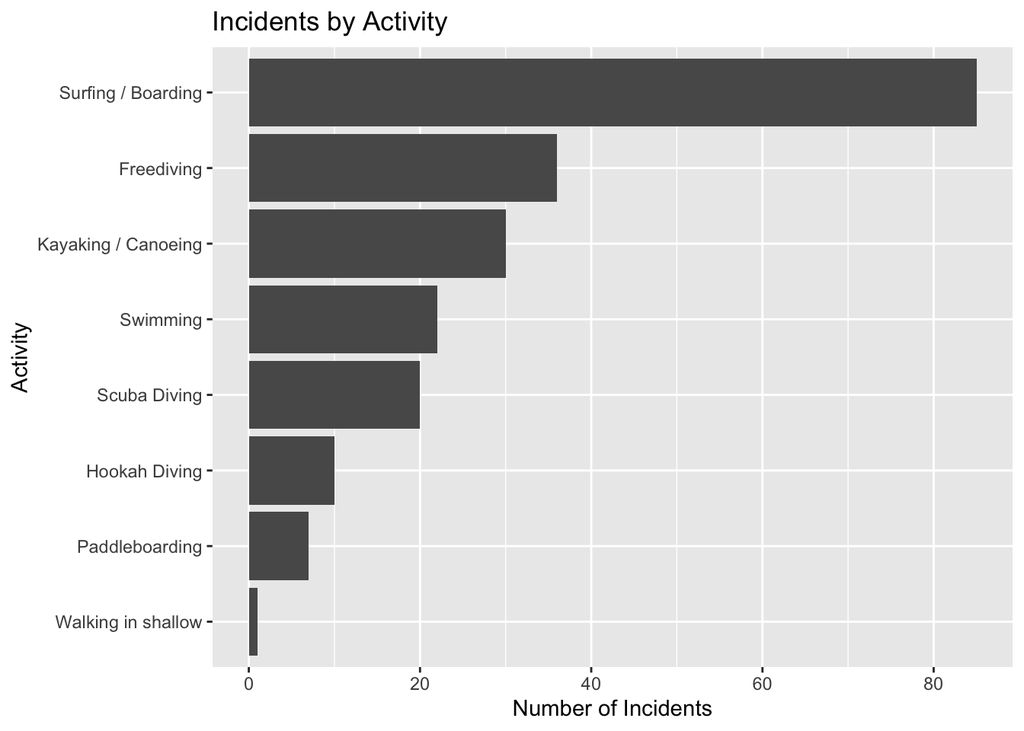

```r
sharks %>%
  filter(!is.na(mode)) %>%
  count(mode, name = "total_incidents") %>%
  ggplot(aes(x = reorder(mode, total_incidents), y = total_incidents)) +
  geom_col() +
  coord_flip() +
  labs(
    title = "Incidents by Activity",
    x = "Activity",
    y = "Number of Incidents"
  )
```

9. Which shark species is involved in the highest number of incidents?

```r
sharks %>%
  filter(!is.na(species)) %>%
  count(species, sort = TRUE)
```

```
## # A tibble: 11 × 2
##    species          n
##    <chr>        <int>
##  1 White          181
##  2 Hammerhead       3
##  3 Blue             2
##  4 Killer Whale     2
##  5 Leopard          2
##  6 Salmon           2
##  7 Blue*            1
##  8 Mako             1
##  9 Sevengill        1
## 10 Thresher         1
## 11 blue             1
```

The Great White shark species is involved in the highest number of incidents (181).

10. Are all incidents involving Great White’s fatal? Make a plot that shows the number and types of incidents for Great White’s only.

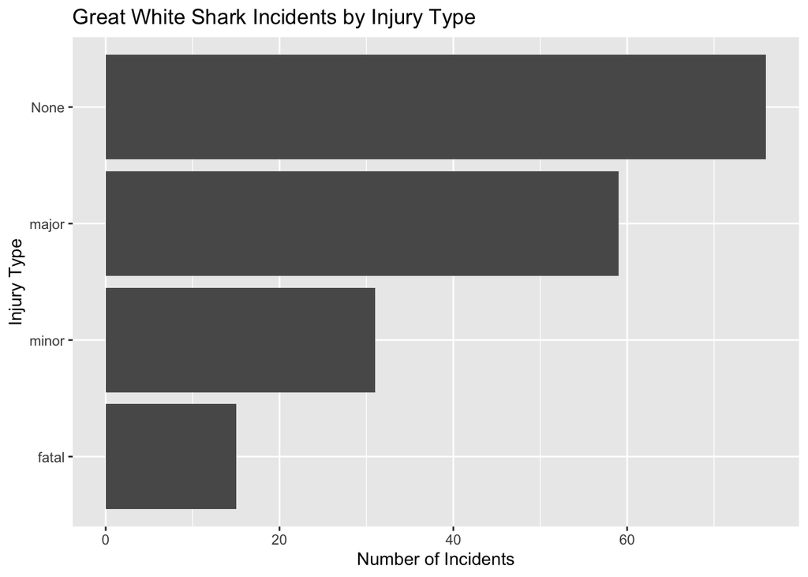

```r
sharks %>%
  filter(species == "White") %>%
  mutate(injury = ifelse(injury == "none" | injury == "none*", "None", injury)) %>%
  count(injury, name = "total_incidents") %>%
  ggplot(aes(x=reorder(injury, total_incidents), y = total_incidents))+
  geom_col()+
  coord_flip()+
  labs(
    title = "Great White Shark Incidents by Injury Type",
    x = "Injury Type",
    y = "Number of Incidents"
  )
```

## Knit and Upload

Please knit your work as an .html file and upload to Canvas. Homework is due before the start of the next lab. No late work is accepted. Make sure to use the formatting conventions of RMarkdown to make your report neat and clean!